# Lecture 08

March 7, 2016

## Bootstrap

Recall in HW01, Exercise 2.14, you simulated

- \(n\) observations from a Normal\((0,1)\) random variable
- used a qqplot and a histogram to evaluate how normal the observations looked

## \(n=15\)

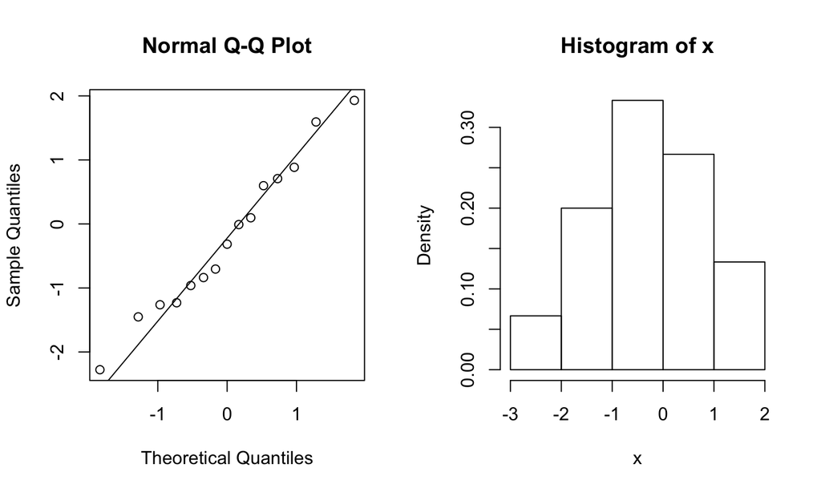

## \(n=100\)

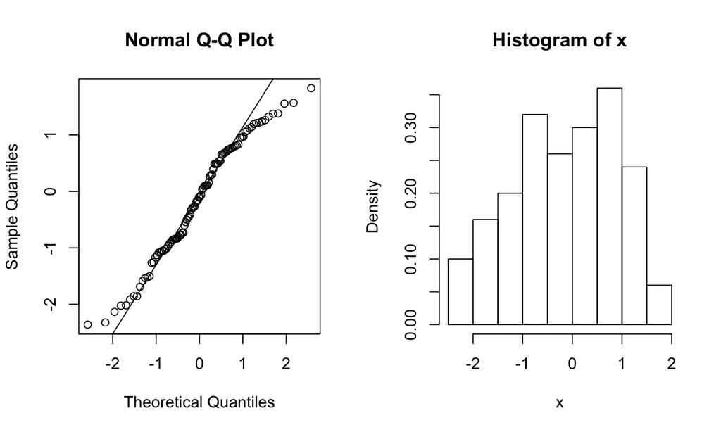

## \(n=1000\)

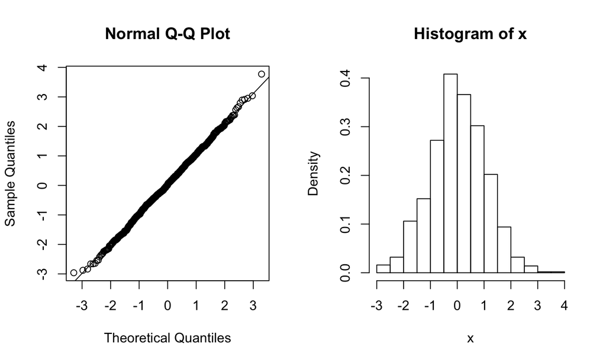

## Moral of the Story

If the sample size \(n\) is big, then the empirical distribution

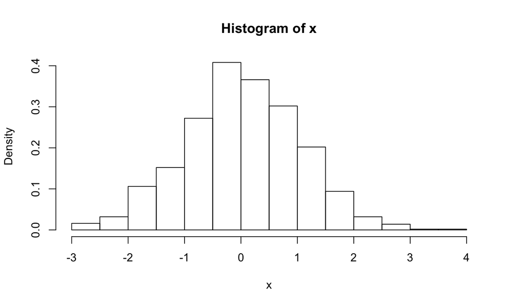

## Moral of the Story

well approximates the true population distribution.

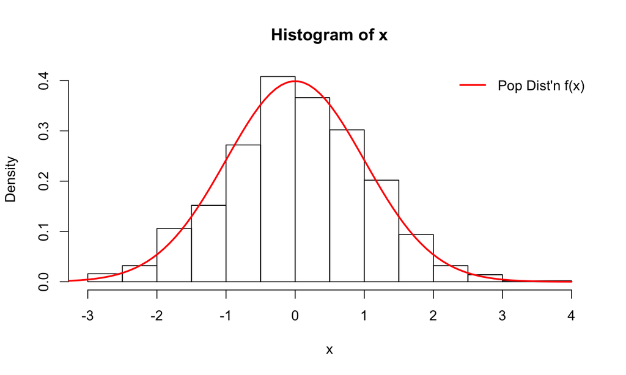

## Bootstrap Motivation

We want to make statements about the **sampling distribution** of some statistic based on samples of size \(n\) from some population distribution.

## Bootstrap Motivation

Typically we won't know the true population distribution…

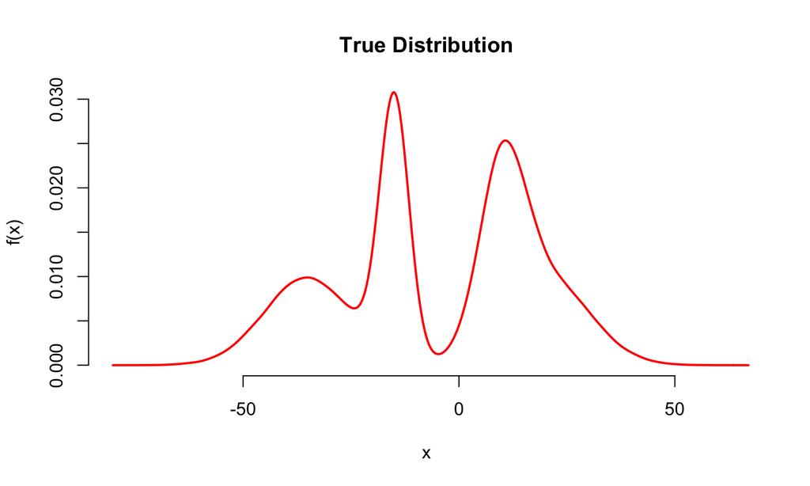

## Bootstrap Motivation

… but we'll have a sample from it:

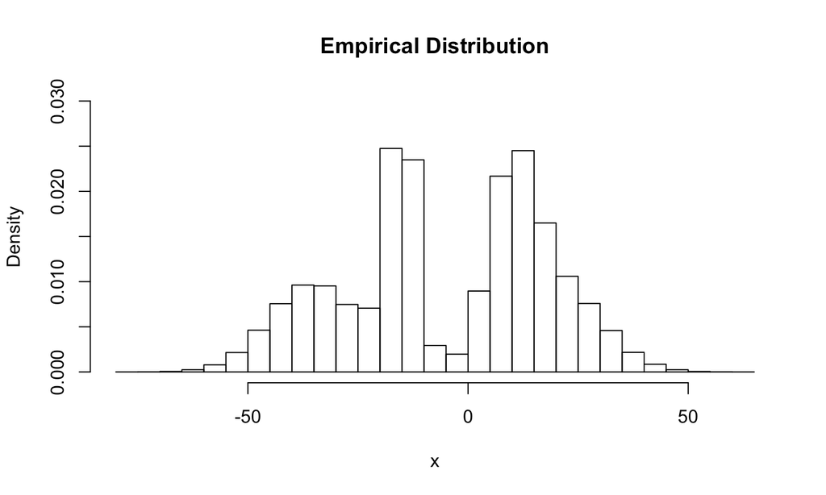

## Bootstrap Motivation

Then **resampling with replacement** from the empirical distribution (left) approximates sampling from the true population distribution (right).

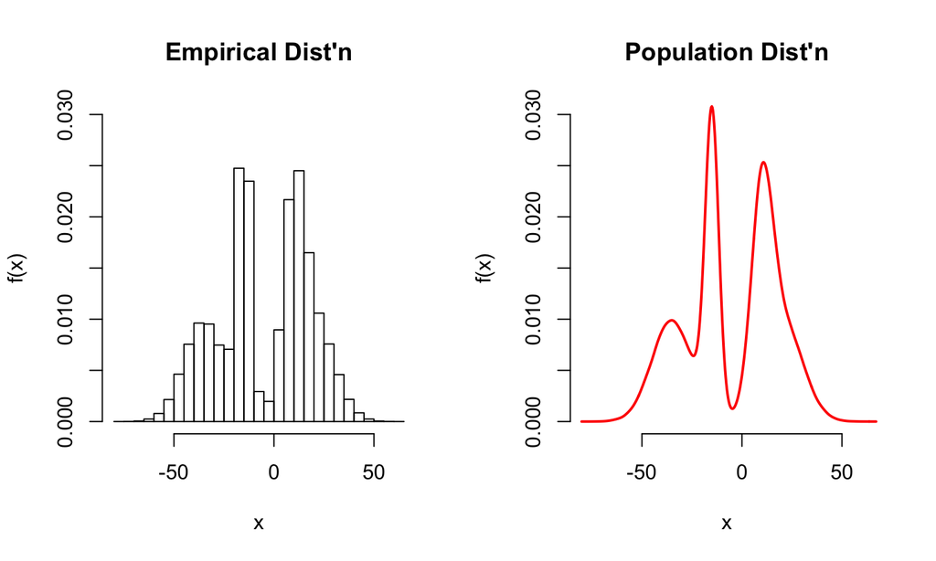

## Example 1: We know result

Ex. where we know the result. Let the population distribution be Normal\((\mu=23, SD=7)\)…

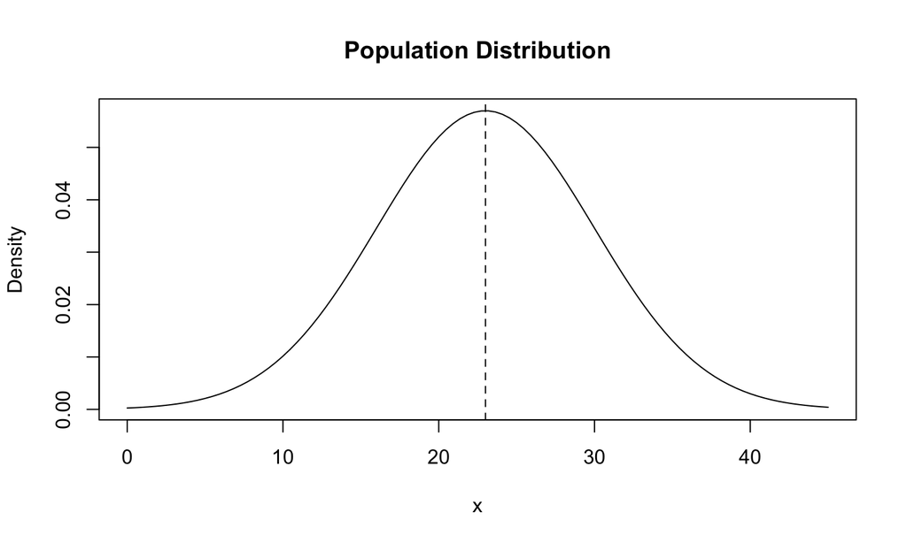

## Example 1: We know result

from which you draw a sample of size \(n=50\). We have \(\overline{x}\) = 22.181 and:

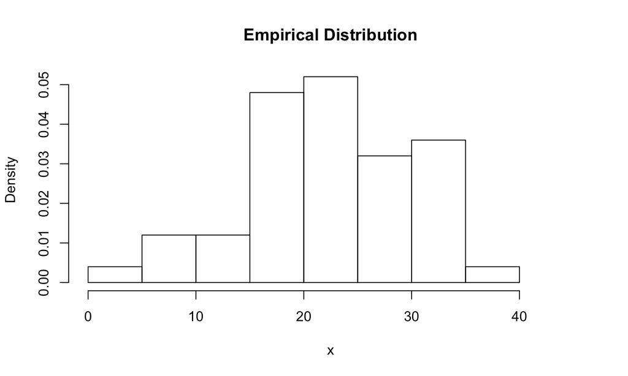

## Example 1: We know result

We **know** the sampling distribution of \(\overline{X}\) is Normal\((\mu=23, SD=7/\sqrt{50}=0.99)\):

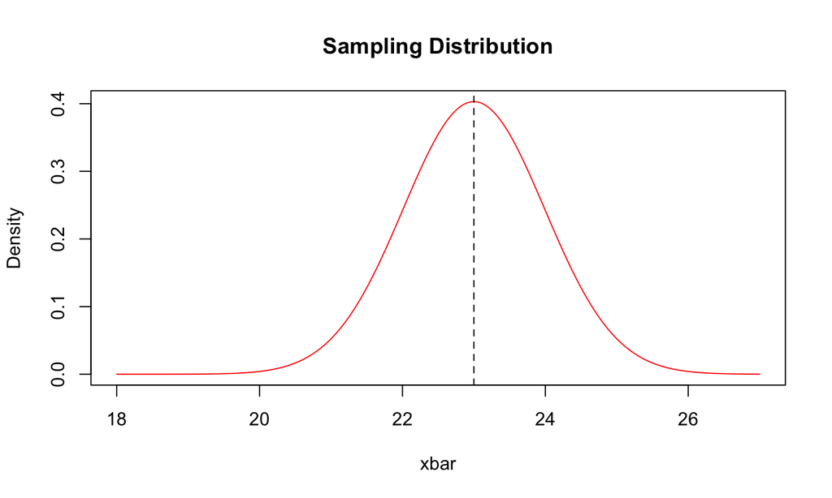

## Example 1: We know result

Run the algorithm:

```r
boot_sample_means <- rep(0, 10000)

for(i in 1:10000){
  boot_resample <- sample(x, replace = TRUE)
  boot_sample_means[i] <- mean(boot_resample)
}
```

## Example 1: We know result

The bootstrap distribution of \(\overline{X}\)…

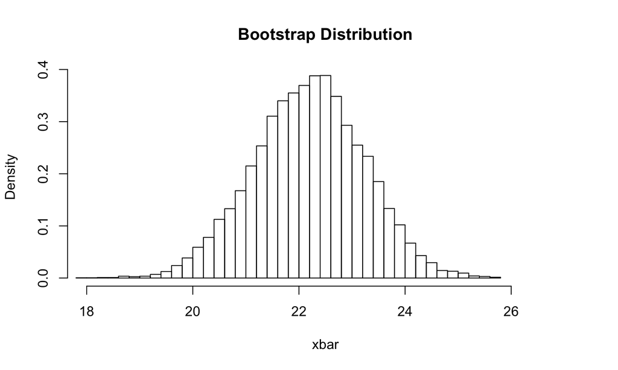

## Example 1: We know result

… is similar in shape and spread as the true sampling distribution but …

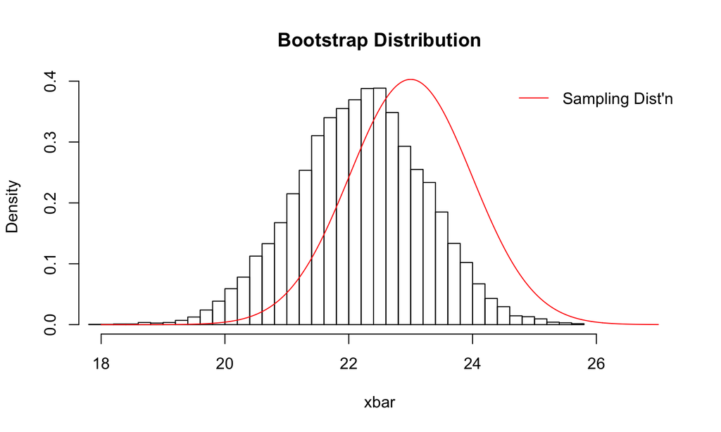

## Example 1: We know result

… it is not centered at \(\mu=23\), rather at \(\overline{x}\) = 22.181.

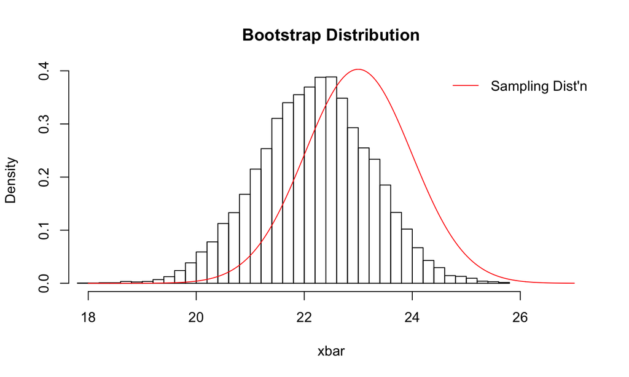

## Example 2: We don't know result

There is **no** result for what the sampling distribution of \(T(\overline{X})\) is, or at least, it's hard to derive. So we create the bootstrap distribution:

## Example 2: We don't know result

```r
boot_sample_WTF <- rep(0, 10000)

for(i in 1:10000){
  boot_resample <- sample(x, replace = TRUE)

  boot_sample_WTF[i] <-
    (max(boot_resample) - min(boot_resample)) /
    median(boot_resample)
}
```

## Example 2: We don't know result

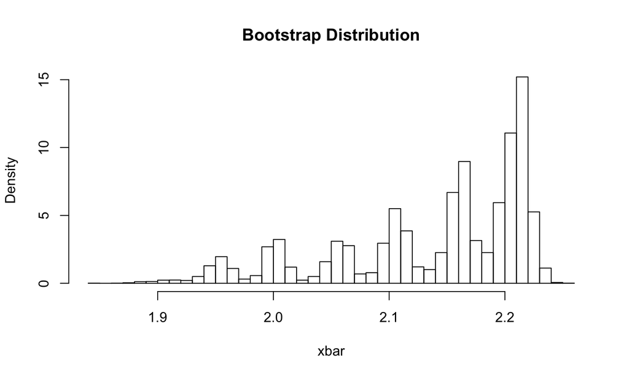

## Example 2: We don't know result

- it is "centered" at \(T(\vec{x})\) = 2.21
- it has SD = 0.082. i.e. the estimate of SE\([T(\vec{X})]\) is 0.082.

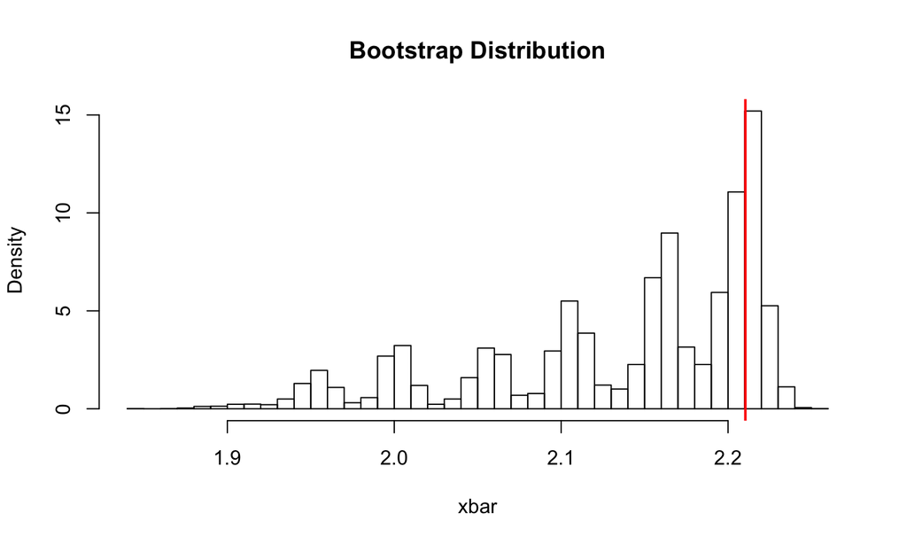